# Study 2

# 1 Results

```r
knitr::opts_chunk$set(echo=TRUE, message=FALSE, warning=FALSE)
# Load packages --------------------------------------------------------------
library(broom)
library(tidyverse)
library(codebook) # to generate codebook
library(here)
library(car) # for the type III SS in ANOVA
library(emmeans)
library(effectsize) # for equivalence tests and effect size estimation
library(GGally) # for ggpairs
library(apastats)
library(ggmosaic)
library(ggpubr)
library(ggtext) # element_markdown
source(here("r", "namifunc.R")) # Read User-Defined Functions

# Load Data Already Prepared for Analysis -------------------------------------------------------
s2_df <- read_rds(here("data_public", "Study2_public.rds"))
s2_df_long <- read_rds(here("data_public", "Study2_public_long.rds"))
## Factorize Essay Conditions
s2_df <- s2_df %>%
  mutate(essay_condition = factor(essay_condition,
                                  levels = c("Social Surrogacy", "Non-Social Surrogacy")))

s2_df_long <- s2_df_long %>%
  mutate(essay_condition = factor(essay_condition,
                                  levels = c("Social Surrogacy", "Non-Social Surrogacy")))
# Descriptives Table ---------------------------------------------------------------------------
## Describe by essay cndition and get mean sd
descriptives_table <- s2_df %>%
  describe_by_factor(essay_condition,
                     vars = c(T1_Heart_1, T1_Valence_1, T1_Arousal_1, T1_Dominance_1,
                              T2_Heart_1, T2_Valence_1, T2_Arousal_1, T2_Dominance_1,
                              IOS, PSI, Single_Immersion,Narrative_Engagement,
                              OTF_Social_World, Enjoyment)) %>%
  # Clean Names
  rename_all(.funs = ~str_replace(., "_1_", "_"))
## Convert descriptives to long via ad-hoc function
descriptives_long <- descriptives_table %>%  get_desc_db()
# e.g.,: get_stats("Non-Social Surrogacy", "Enjoyment", "sd")
get_stats = function(..., d = descriptives_long) d[list(...), value]

## Build in APA
descriptives_APA <- descriptives_long %>%
  select(-name) %>%
  pivot_wider(id_cols = c(variable, essay_condition), values_from = value,
              names_from = stat) %>%
  mutate(APA = to_msd(mean %>% f.round(), sd %>% f.round())) %>%
  data.table::setDT(key = c("essay_condition", "variable"))
get_s2_msd <- function(..., d = descriptives_APA) d[list(...), APA]
```

```r
# Welch's t-test on T2 Belonging comparing non-social surrogacy vs. social surrogacy groups
# Main Analysis t-test
t_results <- s2_df %>%
  # Include only those who passed the attention check
  filter(attention_all_correct == TRUE) %>%
  # t-test comparing the T2 belonging between the essay conditions
  t.test(formula = T2_Heart_1 ~ essay_condition,
         data = .)

# Cohen's d - 90%CI
main_cohens_d_95 <- s2_df %>%
  # Include only those who passed the attention check
  filter(attention_all_correct == TRUE) %>%
  effectsize::cohens_d(x = T2_Heart_1 ~ essay_condition,
           data = ., ci = .95)

# Cohen's d - 90%CI
main_cohens_d <- s2_df %>%
  # Include only those who passed the attention check
  filter(attention_all_correct == TRUE) %>%
  effectsize::cohens_d(x = T2_Heart_1 ~ essay_condition,
           data = ., ci = .90)

# Equivalence Testing
# Equivalence test using d (`equivalence_test.effectsize_table`)
equivalence_results <- equivalence_test(main_cohens_d, range = c(-Cohen_d_target, Cohen_d_target))

# Descriptives as list
descriptives_list <- descriptives_table %>% as.list()

# Main Results List APA Text
heart2_txt <- list(t_results = describe.ttest(t_results),
                   non_surrogate_mean = get_stats("Non-Social Surrogacy", "T2_Heart", "mean"),
                   non_surrogate_sd = get_stats("Non-Social Surrogacy", "T2_Heart", "sd"),
                   surrogate_mean = get_stats("Social Surrogacy", "T2_Heart", "mean"),
                   surrogate_sd = get_stats("Social Surrogacy", "T2_Heart", "sd"),
                   cohen_d = main_cohens_d$Cohens_d %>% round(2),
                   cohen_d_low = main_cohens_d$CI_low %>% round(2),
                   cohen_d_high = main_cohens_d$CI_high %>% round(2),
                   cohen_d_APA = describe_d_ci(main_cohens_d),
                   cohen_d_APA95 = describe_d_ci(main_cohens_d_95))
heart2_txt <- append(heart2_txt,
                     list(non_surrogate_msd = to_msd(heart2_txt$non_surrogate_mean,
                                                     heart2_txt$non_surrogate_sd),
                          surrogate_msd = to_msd(heart2_txt$surrogate_mean,
                                                 heart2_txt$surrogate_sd)))
# Plot
plot_T2_Heart <- s2_df %>%
  # Only include people who got the attention check right
  filter(attention_all_correct == TRUE) %>%
  ggplot(aes(x = essay_condition, color = essay_condition,
             y = T2_Heart_1)) +
  # Violin, errorbar, datapoints
  default_violin +
  # Remove legend
  guides(color = FALSE) +
  # Labels
  labs(y = "Heart Manikin (Time 2)",
       x = "Essay Condition",
       caption = paste("Errorbars represent 95% confidence intervals",
                       paste(heart2_txt$t_results, heart2_txt$cohen_d_APA95, sep = ", "),
                       sep = "<br>")) +
  scale_x_discrete(labels = str_to_title) +
  # save
  ggsave(here("plot","s2_heart2_plot.png"), width = 6, height = 4)
```

**Main Analysis.** I performed Welch’s t-test to compare the post-essaay Heart Manikin scores (Time 2) between the participants who wrote about the social surrogacy video game and the participants who wrote about the social surrogacy video game. Based on the social surrogacy hypothesis, I expected that participants who wrote about the social surrogacy video game would have higher belonging than those who wrote about the non-social surrogacy video game. On the contrary, results showed that participants who wrote about the social surrogacy game (*M* = 6.40, *SD* = 1.90) reported similar levels of belonging compared with those who wrote about a non-surrogacy game (*M* = 6.34, *SD* = 1.93, *t*(351.9) = 0.50, *p* = .621, see Figure 1.1).

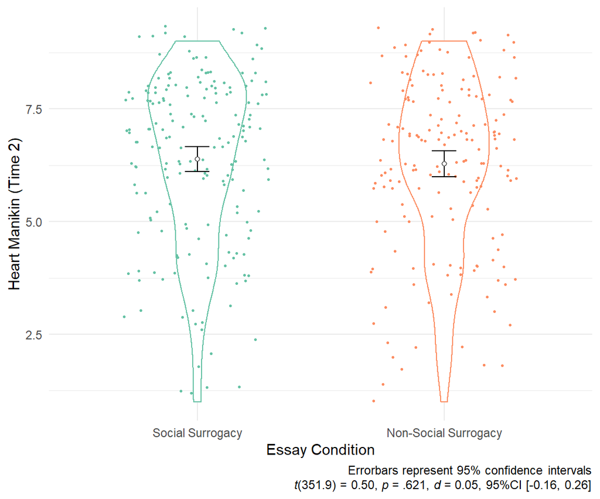

Figure 1.1: Study 2 - Heart Mankin Scores at Time 2 across Essay Conditions

Since the obtained p-value was greater than .05, I performed the two one-sided tests of equivalence to examine if the obtained effect size is theoretically equivalent to zero (Lakens, 2017). I considered the effect size of *d* = 0.35 as the smallest effect size of interest (SESOI). Thus, any effect sizes between *d* = -0.35 and *d* = 0.35 are theoretically equivalent to zero. To compare the observed effect size with the SESOI, I calculated the 90% confidence interval around the observed effect size. Then, I compared this confidence interval with *d* = -0.35 and *d* = 0.35. I set the confidence to 90% because the TOST procedure involves two one-sided tests each with a 5% alpha (Lakens, 2017). Results showed that the observed effect size estimate fell within -0.35 < *d* < 0.35, and its observed confidence interval did not include d = -0.35 or d = 0.35 (*d* = 0.05, 90%CI [-0.12, 0.23]). Thus, I consider that the observed effect size is theoretically equivalent to zero.

```r
# Probing Effectiveness of Rejection Induction.
# T-test
effectivenss <- s2_df %>%
  filter(attention_all_correct == TRUE,
         essay_condition == "Non-Social Surrogacy") %>%
  t.test(formula = Pair(T1_Heart_1, T2_Heart_1) ~ 1, data = .)

# Cohen's d with 95% CI
effectivenss_d_95 <- effectsize::cohens_d(s2_df$T1_Heart_1, s2_df$T2_Heart_1, paird = TRUE,
                              ci = .95)
# Cohen's d with 90%CI
effectivenss_d <- effectsize::cohens_d(s2_df$T1_Heart_1, s2_df$T2_Heart_1, paird = TRUE,
                           ci = .90)
# Equivalence test with 90%CI
effectivenss_equivalence <- equivalence_test(effectivenss_d, range = c(-Cohen_d_target, Cohen_d_target))

# Text
heart12_txt <- list(t_results = describe.ttest(effectivenss),
                    non_surrogate_T1mean = get_stats("Non-Social Surrogacy", "T1_Heart", "mean"),
                    non_surrogate_T1sd = get_stats("Non-Social Surrogacy", "T1_Heart", "sd"),
                    non_surrogate_T2mean = get_stats("Non-Social Surrogacy", "T2_Heart", "mean"),
                    non_surrogate_T2sd = get_stats("Non-Social Surrogacy", "T2_Heart", "sd"),
                    surrogate_T1mean = get_stats("Social Surrogacy", "T1_Heart", "mean"),
                    surrogate_T1sd = get_stats("Social Surrogacy", "T1_Heart", "sd"),
                    surrogate_T2mean = get_stats("Social Surrogacy", "T2_Heart", "mean"),
                    surrogate_T2sd = get_stats("Social Surrogacy", "T2_Heart", "sd"),
                    cohen_d = effectivenss_d$Cohens_d %>% round(2),
                    cohen_d_low = effectivenss_d$CI_low %>% round(2),
                    cohen_d_high = effectivenss_d$CI_high %>% round(2),
                    cohen_d_APA = describe_d_ci(effectivenss_d),
                    cohen_d_APA95 = describe_d_ci(effectivenss_d_95))
heart12_txt <- heart12_txt %>%
  append(list(non_surrogate_T1msd = to_msd(heart12_txt$non_surrogate_T1mean,
                                           heart12_txt$non_surrogate_T1sd),
              surrogate_T1msd = to_msd(heart12_txt$surrogate_T1mean,
                                       heart12_txt$surrogate_T1sd),
              non_surrogate_T2msd = to_msd(heart12_txt$non_surrogate_T2mean,
                                           heart12_txt$non_surrogate_T2sd),
              surrogate_T2msd = to_msd(heart12_txt$surrogate_T2mean,
                                       heart12_txt$surrogate_T2sd)))
```

**Probing Effectiveness of Rejection Induction.** I probed the effectiveness of the rejection induction by comparing the Heart Manikin scores at Times 1 and 2 among the participants in the non-social surrogate game condition. If the rejection induction was effective, I expected that these participants would report lower belonging after the rejection induction (Time 2) compared with the baseline (Time 1). To test this possibility, I ran a paired-samples t-test comparing the Heart Manikin scores at Times 1 vs. 2. Contrary to the prediction, results showed that participants in the non-surrogate essay condition reported similar levels of belonging at Times 1 (baseline, *M* = 6.33, *SD* = 1.95) and 2 (after two essays *M* = 6.34, *SD* = 1.93), *t*(171.0) = 0.06, *p* = .950, see Figure 1.2. Given the non-significant results, I preformed the TOST consistent with the main analysis. Results indicated that the obtained confidence interval fell within the SESOI (*d* = -0.03, 90%CI [-0.15, 0.10]), and thus I consider the effect size as theoretically equivalent to zero.

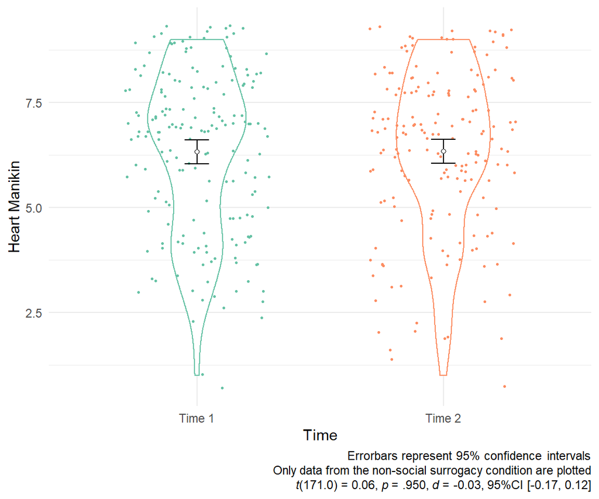

Figure 1.2: Study 2 - Heart Mankin Scores at Times 1 & 2 among the Non-Surrogate Group

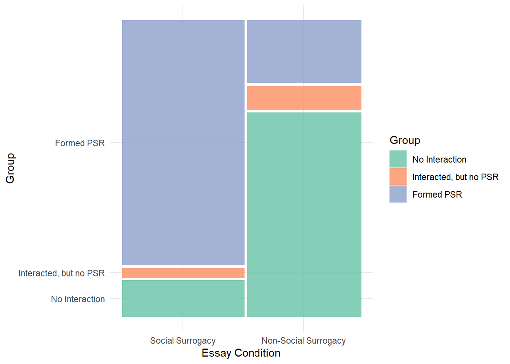

Figure 1.3: Study 2 - Proportions of Participabts who Reported experiencing Parasocial Relationships with an NPC across Conditions

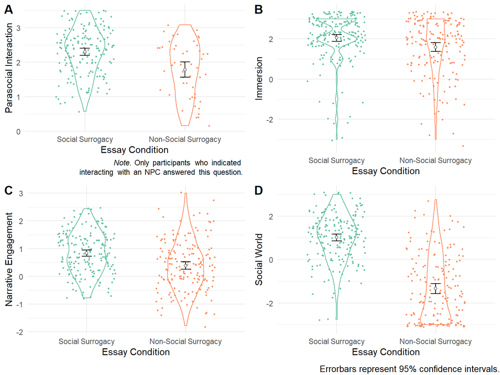

Figure 1.4: Study 2: Exploratory manipulation check items across essay conditions.

```r
# figure of the manipulation check variables -- consider ggpubr::garrange()
ggarrange(plot_PSI, plot_immersion,
          plot_NE,plot_OTFWorld,
          labels = c("A", "B", "C", "D")) %>%
  annotate_figure(bottom = text_grob("Errorbars represent 95% confidence intervals.", color = "black",
                                     hjust = 1, x = 1, size = 10),
                  fig.lab = "", fig.lab.face = "bold") +
  rremove("xlab") +
  # save
  ggsave(here("plot","s2_exp_plots.png"), width = 6, height = 6)
```

To explore the effectiveness of the video game essay in inducing social worlds, I ran a Welch’s t-test to compare the scores of the Single-Item Immersion Scale (Reysen et al., 2019), the Narrative Engagement Scale, and the on-the-fly measure of social world, between social surrogate vs. non-social surrogate video game essay conditions. I expected that rejected participants who wrote about the social surrogacy video game will report higher immersion and social worlds compared with those who wrote about their non-social surrogacy video game. Results were consistent with these predictions. Participants in the social surrogate essay condition reported higher immersion (*M* = 2.03, *SD* = 1.21) than those in the non-social surrogate essay condition (*M* = 1.58, *SD* = 1.41, *t*(332.6) = 3.32, *p* = .001, Figure 1.4, Panel B). Participants in the social surrogate essay condition reported higher narrative engagement (*M* = 0.84, *SD* = 0.77) than those in the non-surrogacy essay condition (*M* = 0.37, *SD* = 0.91, *t*(334.2) = 5.08, *p* < .001, Figure 1.4, Panel C). Participants in the social surrogate essay condition reported higher social worlds (*M* = 0.99, *SD* = 1.14) than those in the non-social surrogate essay condition (*M* = -1.28, *SD* = 1.56, *t*(307.7) = 16.72, *p* < .001, Figure 1.4, Panel D).

Note that the Inclusion of Self in the Other Scale (Aron et al., 1992), the Single-Item Immersion Scale (Reysen et al., 2019), and the on-the-fly measure of social world have never been validated to measure social surrogates in video games, and thus I treat these analyses as exploratory. A failed manipulation check in this context can be ambiguous—such results can imply that (a) the manipulation was ineffective to induce parasocial relationships and social worlds, or (b) the measures were ineffective to capture the manipulated constructs. Accordingly, I do not conclude the effectiveness of the manipulation based on these exploratory analyses.

```r
# Exploratory Analysis of Enjoyment across Social Surrogacy vs. Non-Social Surrogacy Games.
# t-test
enjoyment_results <- s2_df %>%
  # Exclude attention fails
  filter(attention_all_correct == TRUE) %>%
  t.test(formula = Enjoyment ~ essay_condition,
         data = .)
# Plot
enjoyment_plot <- s2_df %>%
  # Exclude attention fails
  filter(attention_all_correct == TRUE) %>%
  ggplot(aes(x = essay_condition, y = Enjoyment, color = essay_condition)) +
  # Default Violin
  default_violin +
  # Labels
  xlab("Essay Condition") +
  guides(color = FALSE) +
  # Sentence case condition labels
  scale_x_discrete(labels = str_to_title) +
  labs(caption = "Errorbars represent 95% confidence intervals")
# Pull APA compatible results
enjoyment_txt <- list(enjoyment_t = describe.ttest(enjoyment_results),
                      non_surrogacy_msd = to_msd(get_stats("Non-Social Surrogacy", "Enjoyment", "mean"),
                                                 get_stats("Non-Social Surrogacy", "Enjoyment", "sd")),
                      surrogacy_msd = to_msd(get_stats("Social Surrogacy", "Enjoyment", "mean"),
                                             get_stats("Social Surrogacy", "Enjoyment", "sd")))
```

**Exploratory Analysis of Enjoyment across Social Surrogacy vs. Non-Social Surrogacy Games.** To explore whether levels of enjoyment differed for social Surrogacy vs. non-social Surrogacy video conditions, I performed Welch’s t-test. I did not have a priori hypothesis for this analysis. Results showed that participants in the social surrogate condition (*M* = 2.42, *SD* = 0.75) reported more enjoyment in playing a game in their essay than those in the non-social surrogate condition (*M* = 2.17, *SD* = 0.79, *t*(334.8) = 3.44, *p* < .001, Figure 1.5).

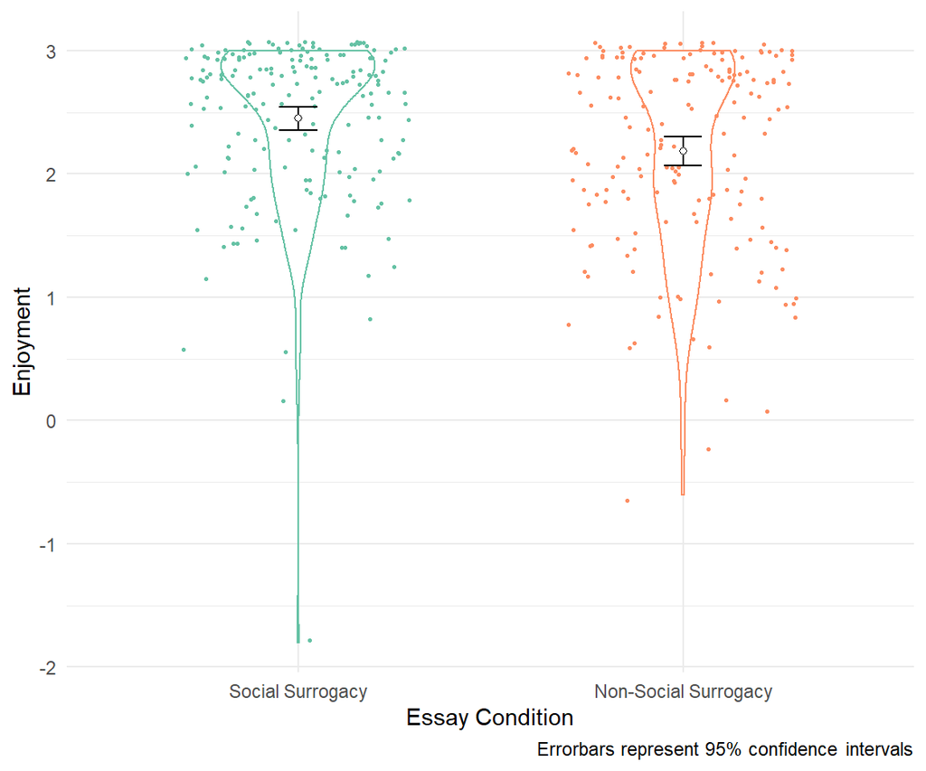

Figure 1.5: Study 2 - Enjoyment across Essay Conditions

```r
enjoyment_plot
```

```r
# T-tests across manikin variables
manikin_ttests <- s2_df %>%
  summarise(across(starts_with(c("T1", "T2")),
                   list(ttest = function(x){list(t.test(x ~ essay_condition))}))) %>%
  # fix names
  rename_all(~gsub("_1", "", .x)) %>%
  # pivot longer so that one row is about one variable
  pivot_longer(everything())


# Extract APA ttests
manikin_ttests <- manikin_ttests %>%
  mutate(tidy = map(value, ~broom::tidy(.)),
         APA = map_chr(value, ~describe.ttest(.))) %>%
  unnest(tidy)


# Two-way Mixed ANOVA Comparing Manikin Scores Across Time x Essay Conditions
manikin_mixed_ANOVAs <- s2_df_long %>%
  summarise(across(c("Heart", "Valence", "Arousal", "Dominance"),
                   list(ANOVA = function(x){
                     rstatix::anova_test(data = cur_data(),
                                wid = PID, dv = cur_column(),
                                within = Time, between = essay_condition) %>% list()},
                     pairTimed = function(x){
                       rstatix::cohens_d(cur_data(),
                                formula = formula(paste(cur_column(), "Time", sep = "~")),
                                paired = TRUE) %>% list()}
                     ))) %>%
  pivot_longer(everything()) %>%
  # Conver to a format with one row = one variable
  mutate(Variable = str_extract(name, "^[^_].+(?=_)"),
         Stat = str_match(name, "(?:[^_](?!_))+$")) %>%
  # Then pivot wider
  pivot_wider(id_cols = Variable,
              names_from = Stat)

# Extract Relevant Stats from the anova object
manikin_ANOVA_DT <- manikin_mixed_ANOVAs %>%
  mutate(ANOVA = map(ANOVA, ~as_tibble(.))) %>%
  unnest(ANOVA) %>% select(Variable:ges, -`p<.05`) %>%
  # Create the APA-compliant text
  mutate(APA = sprintf("_F_(%s,%s) = %s, _p_ %s, $\\eta^2_{G}$ %s",
                       DFn, DFd, `F` %>% apastats::f.round(2), apastats::round.p(p),
                       apastats::round.p(ges))) %>%
  data.table::setDT(key = c("Variable", "Effect"))
# Function to get descriptive stats:
get_manikin_ANOVA_APA = function(..., d = manikin_ANOVA_DT) d[list(...), APA]

# T-test Results
manikin_ttests_DT <- manikin_mixed_ANOVAs %>%
  select(Variable, pairTimed) %>%
  unnest(pairTimed)

# Function to Plot Manikin
plot_manikin_time12 <- function(dataset, y_variable){
  var <- enquo(y_variable)
  var_char <- quo_name(var)
  # Start the ggplot 2 (data from the above)
  ggplot(dataset, aes(x = Time, y = !!var, color = essay_condition)) +
    # Add violin plot
    geom_violin(position = position_dodge(width = 1)) +
    # Add actual data points
    geom_point(size = .6,
               position = "jitter") +
    # Add confidence intervals
    stat_summary(fun.data = mean_cl_normal,
                 fun.args = list(conf.int = .95),
                 geom = "errorbar", width = .2,
                 position = dodge_pos,
                 color = "black") +
    # Add the mean
    geom_point(stat = "summary", fun.data = mean_cl_normal, shape = 21,
               position = dodge_pos, fill = "white", color = "black") +
    # Labels
    scale_y_continuous(name = sprintf("%s Manikin", var_char)) +
    # labs(caption = "Errorbars represent 95% confidence intervals") +
    theme_minimal() +
    # Remove Legends
    guides(fill = FALSE, color = FALSE) +
    scale_x_discrete(labels = str_to_title) +
    facet_wrap(. ~ essay_condition) +
    scale_color_brewer(palette="Set2", name = "Essay Condition")
}

# Combine plots for all manikins by essay and time
manikin12_plots <- ggarrange(plot_manikin_time12(s2_df_long, Heart),
                             plot_manikin_time12(s2_df_long, Valence),
                             plot_manikin_time12(s2_df_long, Arousal),
                             plot_manikin_time12(s2_df_long, Dominance),
                             labels = "AUTO")

manikin_APA <- list(
  ANOVA_Heart_Essay = get_manikin_ANOVA_APA("Heart", "essay_condition"),
  ANOVA_Heart_Time = get_manikin_ANOVA_APA("Heart", "Time"),
  ANOVA_Heart_Int = get_manikin_ANOVA_APA("Heart", "essay_condition:Time"),
  ANOVA_Valence_Essay = get_manikin_ANOVA_APA("Valence", "essay_condition"),
  ANOVA_Valence_Time = get_manikin_ANOVA_APA("Valence", "Time"),
  ANOVA_Valence_Int = get_manikin_ANOVA_APA("Valence", "essay_condition:Time"),
  ANOVA_Arousal_Essay = get_manikin_ANOVA_APA("Arousal", "essay_condition"),
  ANOVA_Arousal_Time = get_manikin_ANOVA_APA("Arousal", "Time"),
  ANOVA_Arousal_Int = get_manikin_ANOVA_APA("Arousal", "essay_condition:Time"),
  ANOVA_Dominance_Essay = get_manikin_ANOVA_APA("Dominance", "essay_condition"),
  ANOVA_Dominance_Time = get_manikin_ANOVA_APA("Dominance", "Time"),
  ANOVA_Dominance_Int = get_manikin_ANOVA_APA("Dominance", "essay_condition:Time")
)
```

**Non-Preregistered Exploratory Analyses.** To probe whether participants experienced different arousal, valence, dominance, after writing a social surrogate vs. non-surrogate essay, I ran 2 (Essay Condition: Social Surrogacy vs. Non-Social Surrogacy) x 2 (Time: Time 1 vs. Time 2) Mixed ANOVAs on the Self-Assessment Manikin Scores. For the Heart Manikin scores, there was no main effect of the Essay (*F*(1,366) = 0.01, *p* = .909, $\eta^2_{G}$ < .001), no main effect of Time (*F*(1,366) = 0.42, *p* = .515, $\eta^2_{G}$ < .001), and no Essay Type x Time interaction interaction (*F*(1,366) = 0.33, *p* = .568, $\eta^2_{G}$ < .001). For the original Self-Assessment Manikins (Valence, Arousal, and Dominance), there were no main effect of the Essay type (*F*(1,366) = 0.27, *p* = .605, $\eta^2_{G}$ < .001 for valence, *F*(1,365) = 0.10, *p* = .747, $\eta^2_{G}$ < .001 for arousal, and *F*(1,366) = 0.38, *p* = .536, $\eta^2_{G}$ < .001 for dominance) or no Essay x Time interaction (*F*(1,366) = 3.84, *p* = .051, $\eta^2_{G}$ < .001 for valence, *F*(1,365) = 1.99, *p* = .160, $\eta^2_{G}$ < .001 for arousal, and *F*(1,366) = 0.13, *p* = .723, $\eta^2_{G}$ < .001 for dominance). However, there were main effects of Time across these measures (*F*(1,366) = 15.11, *p* < .001, $\eta^2_{G}$ = .006 for valence, *F*(1,365) = 58.13, *p* < .001, $\eta^2_{G}$ = .030 for arousal, and *F*(1,366) = 25.22, *p* < .001, $\eta^2_{G}$ = .006 for dominance), suggesting that participants reported higher valence, arousal, and dominance at Time 2 than Time 2.

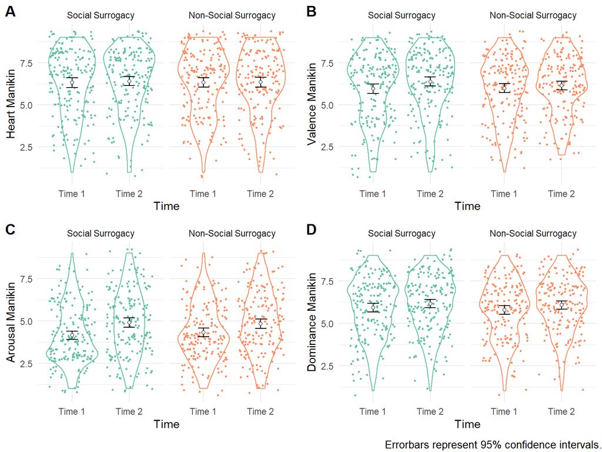

Figure 1.6: Study 2 - Manikin Scores Across Conditions

```r
manikin12_plots %>%
  # Add caption
  annotate_figure(bottom = text_grob("Errorbars represent 95% confidence intervals.", color = "black",
                                     hjust = 1, x = 1, size = 10)) +
  # Save
  ggsave(here("plot","s2_manikin12_plots.png"), width = 6, height = 6)
```

```r
# Resources
# Rmarkdown Mathematical Notations - https://rpruim.github.io/s341/S19/from-class/MathinRmd.html
# Generalized eta-squared- https://link.springer.com/article/10.3758/BF03192707#:~:text=Only%20recently%20has%20a%20generally,Olejnik%20%26%20Algina%2C%202003).
```

# 2 Discussion

Based on Hypothesis 1, I expected that participants in the social surrogacy game condition report more belonging than those in the non-social surrogacy game condition. The current results did not confirm this hypothesis. Instead, the people who wrote about the social surrogate video game reported similar levels of belonging compared with the people who wrote about non-social surrogate game. The difference was theoretically equivalence to zero according the equivalence test.

The current null results can imply many possibilities.

The first possibility is that the current study had methodological flaws that prevented from testing the hypothesis. Such flaws can include (a) Type II error, (a) ineffective induction of social rejection, (b) ineffective manipulation of social surrogacy games, and (c) ineffective measurement of belonging.

Another possibility for the null result is that writing about non-social surrogacy games provided belonging. The social surrogacy hypothesis suggests that people can replenish belonging via a reminder of others—non-human entities that reminds of social connections such as pictures of friends, comfort food, and Facebook updates (Gabriel & Valenti, 2017). The non-social surrogate games in the current study could have served as reminders of others in a similar manner. For example, people who played Tetris with their close friends can remember their social connections while thinking about Tetris, and thus replenishing belonging. In Study 3, I will eliminate this possibility by asking participants play a novel video game that they have never played before.